# UFood Data Analyst Case

**Company Background:**  
UFood is Brazil’s leading food delivery app, operating in 1,000+ cities with nearly 1M annual consumers.  
**Problem:** Engagement and campaign performance are declining, threatening growth.  
**Objective:**

1. Explore customer & campaign data to identify insights.
2. Propose customer segmentation based on behaviors.
3. Recommend data-driven actions to optimize marketing performance.

## EDA (Exploratory Data Analysis)

```python
# Import Libraries
import pandas as pd
import numpy as np
import matplotlib.pyplot as plt
import seaborn as sns
```

```python
# Load & Inspect Data
food = pd.read_csv(r'/Users/surajshrestha/Desktop/Analyst builder/Jupyter Notebook/Food Marketing Data Analysis Project/Data/u_food_marketing.csv')

# Quick look
display(food.head())
display(food.info())
display(food.describe())
```

|  | Income | Kidhome | Teenhome | Recency | MntWines | MntFruits | MntMeatProducts | MntFishProducts | MntSweetProducts | MntGoldProds | ... | marital_Together | marital_Widow | education_2n Cycle | education_Basic | education_Graduation | education_Master | education_PhD | MntTotal | MntRegularProds | AcceptedCmpOverall |
| --- | --- | --- | --- | --- | --- | --- | --- | --- | --- | --- | --- | --- | --- | --- | --- | --- | --- | --- | --- | --- | --- |
| 0 | 58138.0 | 0 | 0 | 58 | 635 | 88 | 546 | 172 | 88 | 88 | ... | 0 | 0 | 0 | 0 | 1 | 0 | 0 | 1529 | 1441 | 0 |
| 1 | 46344.0 | 1 | 1 | 38 | 11 | 1 | 6 | 2 | 1 | 6 | ... | 0 | 0 | 0 | 0 | 1 | 0 | 0 | 21 | 15 | 0 |
| 2 | 71613.0 | 0 | 0 | 26 | 426 | 49 | 127 | 111 | 21 | 42 | ... | 1 | 0 | 0 | 0 | 1 | 0 | 0 | 734 | 692 | 0 |
| 3 | 26646.0 | 1 | 0 | 26 | 11 | 4 | 20 | 10 | 3 | 5 | ... | 1 | 0 | 0 | 0 | 1 | 0 | 0 | 48 | 43 | 0 |
| 4 | 58293.0 | 1 | 0 | 94 | 173 | 43 | 118 | 46 | 27 | 15 | ... | 0 | 0 | 0 | 0 | 0 | 0 | 1 | 407 | 392 | 0 |

5 rows × 39 columns

```
<class 'pandas.core.frame.DataFrame'>
RangeIndex: 2205 entries, 0 to 2204
Data columns (total 39 columns):
 #   Column                Non-Null Count  Dtype
---  ------                --------------  -----
 0   Income                2205 non-null   float64
 1   Kidhome               2205 non-null   int64
 2   Teenhome              2205 non-null   int64
 3   Recency               2205 non-null   int64
 4   MntWines              2205 non-null   int64
 5   MntFruits             2205 non-null   int64
 6   MntMeatProducts       2205 non-null   int64
 7   MntFishProducts       2205 non-null   int64
 8   MntSweetProducts      2205 non-null   int64
 9   MntGoldProds          2205 non-null   int64
```

[output cut: 31 more lines]

```
None
```

|  | Income | Kidhome | Teenhome | Recency | MntWines | MntFruits | MntMeatProducts | MntFishProducts | MntSweetProducts | MntGoldProds | ... | marital_Together | marital_Widow | education_2n Cycle | education_Basic | education_Graduation | education_Master | education_PhD | MntTotal | MntRegularProds | AcceptedCmpOverall |
| --- | --- | --- | --- | --- | --- | --- | --- | --- | --- | --- | --- | --- | --- | --- | --- | --- | --- | --- | --- | --- | --- |
| count | 2205.000000 | 2205.000000 | 2205.000000 | 2205.000000 | 2205.000000 | 2205.000000 | 2205.000000 | 2205.000000 | 2205.000000 | 2205.000000 | ... | 2205.000000 | 2205.000000 | 2205.000000 | 2205.000000 | 2205.000000 | 2205.000000 | 2205.000000 | 2205.000000 | 2205.000000 | 2205.00000 |
| mean | 51622.094785 | 0.442177 | 0.506576 | 49.009070 | 306.164626 | 26.403175 | 165.312018 | 37.756463 | 27.128345 | 44.057143 | ... | 0.257596 | 0.034467 | 0.089796 | 0.024490 | 0.504762 | 0.165079 | 0.215873 | 562.764626 | 518.707483 | 0.29932 |
| std | 20713.063826 | 0.537132 | 0.544380 | 28.932111 | 337.493839 | 39.784484 | 217.784507 | 54.824635 | 41.130468 | 51.736211 | ... | 0.437410 | 0.182467 | 0.285954 | 0.154599 | 0.500091 | 0.371336 | 0.411520 | 575.936911 | 553.847248 | 0.68044 |
| min | 1730.000000 | 0.000000 | 0.000000 | 0.000000 | 0.000000 | 0.000000 | 0.000000 | 0.000000 | 0.000000 | 0.000000 | ... | 0.000000 | 0.000000 | 0.000000 | 0.000000 | 0.000000 | 0.000000 | 0.000000 | 4.000000 | -283.000000 | 0.00000 |
| 25% | 35196.000000 | 0.000000 | 0.000000 | 24.000000 | 24.000000 | 2.000000 | 16.000000 | 3.000000 | 1.000000 | 9.000000 | ... | 0.000000 | 0.000000 | 0.000000 | 0.000000 | 0.000000 | 0.000000 | 0.000000 | 56.000000 | 42.000000 | 0.00000 |
| 50% | 51287.000000 | 0.000000 | 0.000000 | 49.000000 | 178.000000 | 8.000000 | 68.000000 | 12.000000 | 8.000000 | 25.000000 | ... | 0.000000 | 0.000000 | 0.000000 | 0.000000 | 1.000000 | 0.000000 | 0.000000 | 343.000000 | 288.000000 | 0.00000 |
| 75% | 68281.000000 | 1.000000 | 1.000000 | 74.000000 | 507.000000 | 33.000000 | 232.000000 | 50.000000 | 34.000000 | 56.000000 | ... | 1.000000 | 0.000000 | 0.000000 | 0.000000 | 1.000000 | 0.000000 | 0.000000 | 964.000000 | 884.000000 | 0.00000 |
| max | 113734.000000 | 2.000000 | 2.000000 | 99.000000 | 1493.000000 | 199.000000 | 1725.000000 | 259.000000 | 262.000000 | 321.000000 | ... | 1.000000 | 1.000000 | 1.000000 | 1.000000 | 1.000000 | 1.000000 | 1.000000 | 2491.000000 | 2458.000000 | 4.00000 |

8 rows × 39 columns

### Data Cleaning & Preprocessing

```python
# Convert Income to integer
food['Income'] = food['Income'].round().astype(int)

# Drop missing values (optional: could also impute)
food = food.dropna()

# remove duplicates
food.drop_duplicates(keep = False, inplace = True)

# Confirm data types
food.info()
```

```
<class 'pandas.core.frame.DataFrame'>
Index: 1843 entries, 0 to 2204
Data columns (total 39 columns):
 #   Column                Non-Null Count  Dtype
---  ------                --------------  -----
 0   Income                1843 non-null   int64
 1   Kidhome               1843 non-null   int64
 2   Teenhome              1843 non-null   int64
 3   Recency               1843 non-null   int64
 4   MntWines              1843 non-null   int64
 5   MntFruits             1843 non-null   int64
 6   MntMeatProducts       1843 non-null   int64
 7   MntFishProducts       1843 non-null   int64
 8   MntSweetProducts      1843 non-null   int64
 9   MntGoldProds          1843 non-null   int64
```

[output cut: 31 more lines]

```python
# combining kidhome and teenhome as Total_Children
food['Total_Children'] = food[['Kidhome', 'Teenhome']].sum(axis=1)
```

```python
# assigning marital statuses with individual number or category and combining them into a single column
food['marital_Divorced'] = food['marital_Divorced'].replace({1:5, 0:0})
food['marital_Married'] = food['marital_Married'].replace({1:4, 0:0})
food['marital_Single'] = food['marital_Single'].replace({1:3, 0:0})
food['marital_Together'] = food['marital_Together'].replace({1:2, 0:0})
food['marital_Widow'] = food['marital_Widow'].replace({1:1, 0:0})

food['Marital_Status'] = food[['marital_Divorced', 'marital_Married', 'marital_Single', 'marital_Together', 'marital_Widow']].sum(axis=1)
```

```python
# assigning related marital status string to the column
food['Marital_Status_str'] = food['Marital_Status']. map({5: 'Divorced', 4: 'Married', 3: 'Single', 2: 'Together', 1: 'Widow'})
```

```python
# doing the same with the education statuses
food['education_2n Cycle'] = food['education_2n Cycle'].replace({1:1, 0:0})
food['education_Basic'] = food['education_Basic'].replace({1:2, 0:0})
food['education_Graduation'] = food['education_Graduation'].replace({1:3, 0:0})
food['education_Master'] = food['education_Master'].replace({1:4, 0:0})
food['education_PhD'] = food['education_PhD'].replace({1:5, 0:0})

food['Education_Status'] = food[['education_2n Cycle', 'education_Basic', 'education_Graduation', 'education_Master', 'education_PhD']].sum(axis=1)
```

```python
# creating a new column named 'Accepted_Campaign' which records the total number of campaigns accepted
food['Accepted_Campaigns'] = food[['AcceptedCmp3', 'AcceptedCmp4', 'AcceptedCmp5', 'AcceptedCmp2', 'AcceptedCmp1']].sum(axis=1)
```

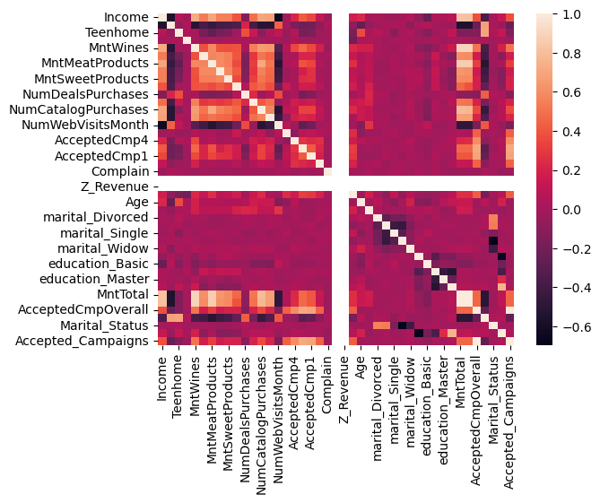

```python
# correlation plot
sns.heatmap(food.corr(method = 'pearson', numeric_only=True))
```

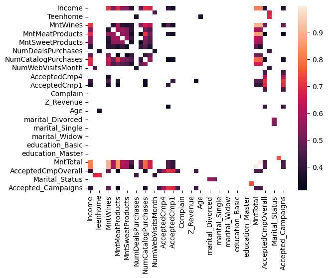

```python
# checking correlations which are > 0.3 and are < 1
all_correlations = food.corr(method = 'pearson', numeric_only=True)
all_correlations = all_correlations[(all_correlations > 0.3) & (all_correlations < 1)]

sns.heatmap(all_correlations)
```

```python
# correlation check only for Accepted Campaigns
all_correlations['Accepted_Campaigns']
```

```
Income                  0.384189
Kidhome                      NaN
Teenhome                     NaN
Recency                      NaN
MntWines                0.496881
MntFruits                    NaN
MntMeatProducts         0.314922
MntFishProducts              NaN
MntSweetProducts             NaN
MntGoldProds                 NaN
NumDealsPurchases            NaN
NumWebPurchases              NaN
NumCatalogPurchases     0.361530
NumStorePurchases            NaN
NumWebVisitsMonth            NaN
AcceptedCmp3            0.433521
AcceptedCmp4            0.600645
AcceptedCmp5            0.710378
AcceptedCmp1            0.688068
AcceptedCmp2            0.442677
Complain                     NaN
Z_CostContact                NaN
Z_Revenue                    NaN
Response                0.418309
Age                          NaN
Customer_Days                NaN
marital_Divorced             NaN
marital_Married              NaN
marital_Single               NaN
marital_Together             NaN
marital_Widow                NaN
education_2n Cycle           NaN
education_Basic              NaN
education_Graduation         NaN
education_Master             NaN
education_PhD                NaN
MntTotal                0.452785
MntRegularProds         0.452599
AcceptedCmpOverall           NaN
Total_Children               NaN
Marital_Status               NaN
Education_Status             NaN
Accepted_Campaigns           NaN
Name: Accepted_Campaigns, dtype: float64
```

### Looks like, among types of purchases, Catalog purchases are more likely to increase campaign acceptance and total amount spent has a positive correlation with campaign acceptance.

### People are likely to spend more if the accept campaign/s.

## Age Groups

```python
# defining age groups or boxes
age_groups = [(20,30), (31,40), (41,50), (51,60), (61,70), (71, 85)]

def assign_age_group(Age):
    for age_range in age_groups:
        if age_range[0] <= Age <= age_range[1]:
            return f"{age_range[0]} - {age_range[1]}"
    return("Unkown")

# adding Age_Group column to the data
food['Age_Group'] = food['Age'].apply(assign_age_group)
```

```python
# glancing at the age groups
food[['Age', 'Age_Group']].head()
```

|  | Age | Age_Group |
| --- | --- | --- |
| 0 | 63 | 61 - 70 |
| 1 | 66 | 61 - 70 |
| 2 | 55 | 51 - 60 |
| 3 | 36 | 31 - 40 |
| 4 | 39 | 31 - 40 |

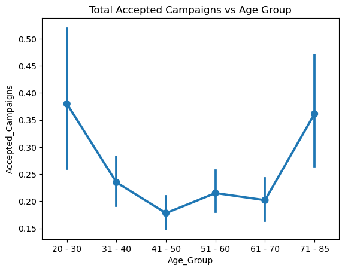

```python
# visualizing Age Group vs the people who Accepted Campaigns
age_order = ['20 - 30', '31 - 40', '41 - 50', '51 - 60', '61 - 70', '71 - 85']

sns.pointplot(data = food, x = 'Age_Group', y = 'Accepted_Campaigns', order = age_order)
plt.title('Total Accepted Campaigns vs Age Group')
```

### The confidence intervals for age groups of 20-30 and 71-85 are too wide. Maybe the data is not enough for those groups.

```python
# checking for age_group distribution
```

```python
counts = food['Age_Group'].value_counts()
```

```python
percentage = counts / food.shape[0]
```

```python
percent_food = percentage.reset_index()
```

```python
percent_food.columns = ['age_group', 'percentage']
```

```python
percent_food = percent_food.sort_values('age_group')
```

```python
percent_food
```

|  | age_group | percentage |
| --- | --- | --- |
| 5 | 20 - 30 | 0.027130 |
| 3 | 31 - 40 | 0.161693 |
| 0 | 41 - 50 | 0.332067 |
| 1 | 51 - 60 | 0.221921 |
| 2 | 61 - 70 | 0.212154 |
| 4 | 71 - 85 | 0.045035 |

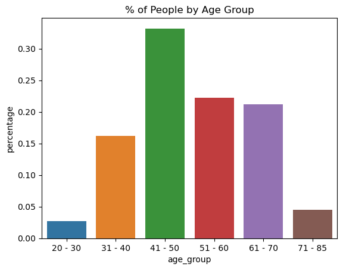

```python
# visualizing the age_group distribution
sns.barplot(x = 'age_group', y = 'percentage', data = percent_food)
plt.title('% of People by Age Group')
plt.show()
```

### Core audience for accepting campaigns right now is 31 - 70 year olds

```python
# Age group vs Total Amount Spent
food.groupby('Age_Group')['MntTotal'].sum().reset_index()
```

|  | Age_Group | MntTotal |
| --- | --- | --- |
| 0 | 20 - 30 | 40166 |
| 1 | 31 - 40 | 135044 |
| 2 | 41 - 50 | 297347 |
| 3 | 51 - 60 | 242313 |
| 4 | 61 - 70 | 249793 |
| 5 | 71 - 85 | 76828 |

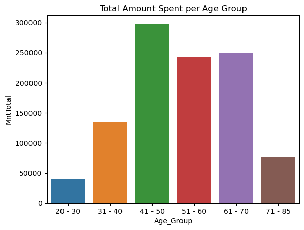

```python
# visualizing Amount spent per age group
grouped_food = food.groupby('Age_Group')['MntTotal'].sum().reset_index()

sns.barplot(x = 'Age_Group', y = 'MntTotal', data = grouped_food)
plt.title('Total Amount Spent per Age Group')
plt.show()
```

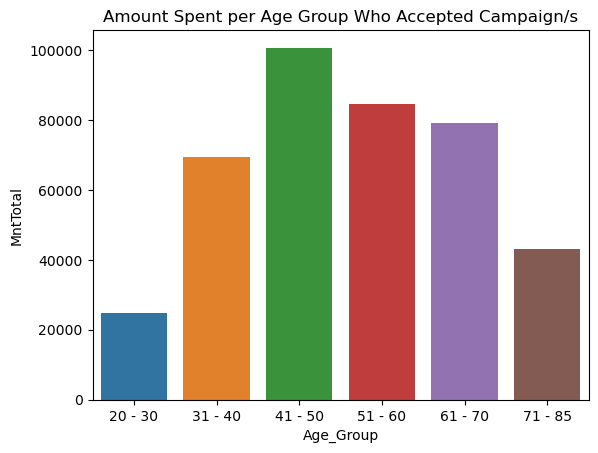

```python
# total amount spent per age group who accepted campaign/s
acct_camp = food[food['Accepted_Campaigns'] != 0]

grouped_food = acct_camp.groupby('Age_Group')['MntTotal'].sum().reset_index()

sns.barplot(x = 'Age_Group', y = 'MntTotal', data = grouped_food)
plt.title('Amount Spent per Age Group Who Accepted Campaign/s')
plt.show()
```

## Type of Purchases

```python
# total number of purchases by purchase type
```

```python
sum_food = pd.DataFrame(food [ ['NumWebPurchases', 'NumCatalogPurchases', 'NumStorePurchases'] ].sum(), columns = ['Sums'])
```

```python
sum_food = sum_food.reset_index()
```

```python
sum_food.rename(columns = {'index': 'Type_of_Purchase'}, inplace = True)
```

```python
sum_food
```

|  | Type_of_Purchase | Sums |
| --- | --- | --- |
| 0 | NumWebPurchases | 7619 |
| 1 | NumCatalogPurchases | 4871 |
| 2 | NumStorePurchases | 10675 |

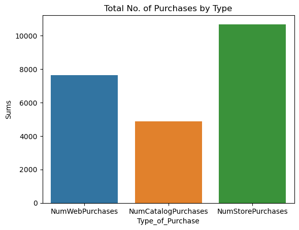

```python
sns.barplot(x = 'Type_of_Purchase', y = 'Sums', data = sum_food)
plt.title('Total No. of Purchases by Type')
```

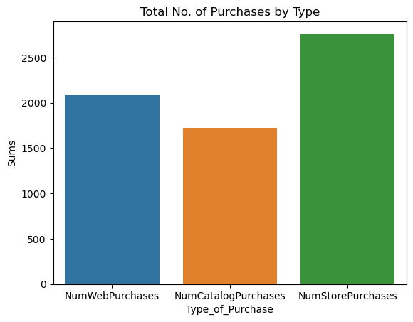

```python
# filterring by people who accepted campaigns
acct_camp = food[food['Accepted_Campaigns'] != 0]

sum_food = pd.DataFrame(acct_camp [ ['NumWebPurchases', 'NumCatalogPurchases', 'NumStorePurchases'] ].sum(), columns = ['Sums'])
sum_food = sum_food.reset_index()
sum_food.rename(columns = {'index': 'Type_of_Purchase'}, inplace = True)

sns.barplot(x = 'Type_of_Purchase', y = 'Sums', data = sum_food)
plt.title('Total No. of Purchases by Type')
```

### There is higher amount of in-store purchases than web and catalog purchases regardless of campaign acceptance or not.

```python
import warnings
warnings.filterwarnings("ignore", category=FutureWarning)
```

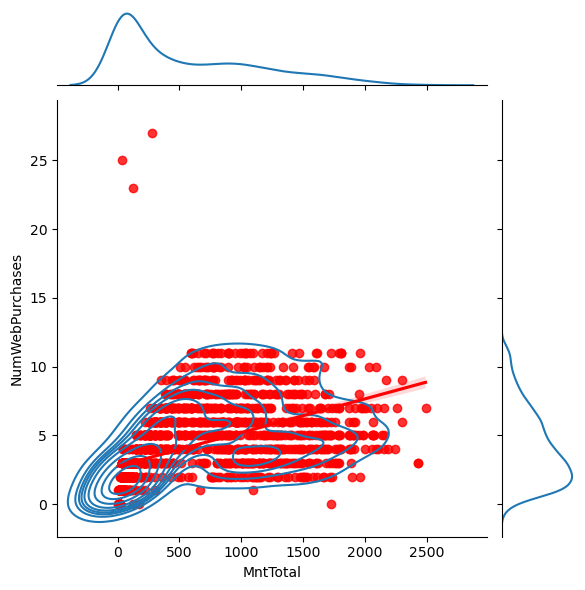

```python
# visualizing total amount spent vs Number of Web Purchases
x = sns.jointplot(data = food, x = 'MntTotal', y = 'NumWebPurchases', kind = "kde")
x.plot_joint(sns.regplot, color = 'red')
```

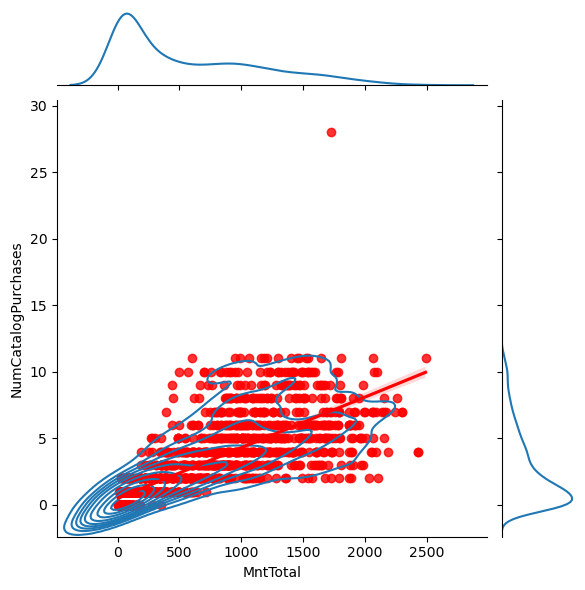

```python
# visualizing total amount spent vs Number of Catalog Purchases
x = sns.jointplot(data = food, x = 'MntTotal', y = 'NumCatalogPurchases', kind = "kde")
x.plot_joint(sns.regplot, color = 'red')
```

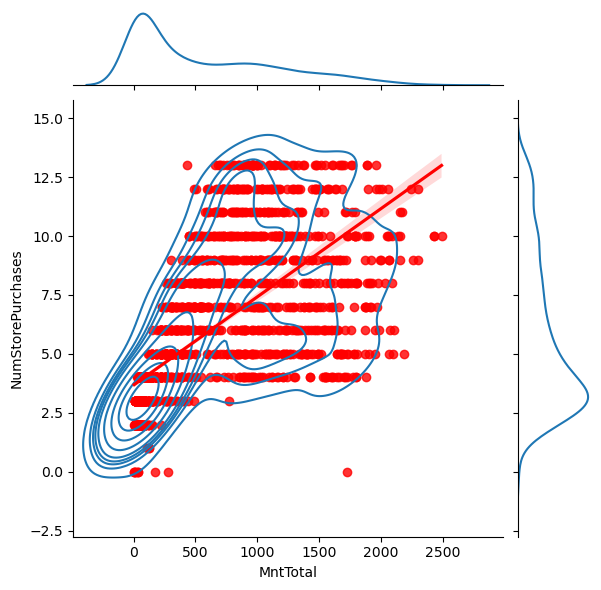

```python
# visualizing total amount spent vs Number of In-Store Purchases
x = sns.jointplot(data = food, x = 'MntTotal', y = 'NumStorePurchases', kind = "kde")
x.plot_joint(sns.regplot, color = 'red')
```

### Directions: Boost up the higher percentage catalog customers. OR Focus on IN Store/Web because they have more traffic.

## People with Children

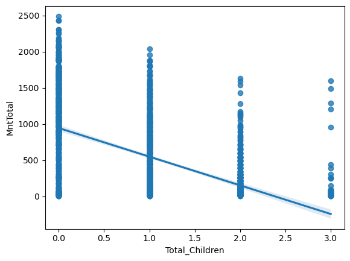

```python
# regression plot of total children vs total amount spent
sns.regplot(x = 'Total_Children', y = 'MntTotal', data = food)
```

### Total_Children has a negative correlation wih Total Amount Spent.

### People with more kids are less likely to spend more.

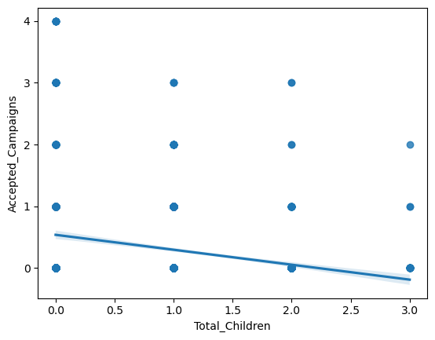

```python
# regression plot of total children vs total accepted campaigns
sns.regplot(x = 'Total_Children', y = 'Accepted_Campaigns', data = food)
```

### Total_Children has a negatice correlation wih Accepted_Campaigns.

### People with less kids are more Likely to accept campaign.

## Education Status Segmentation

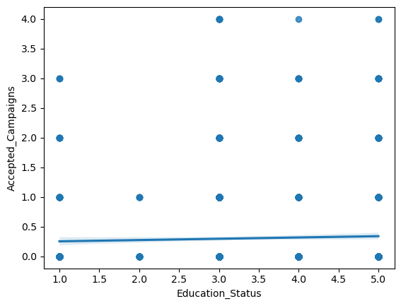

```python
# regression plot of Education Status vs Accepted Campaigns
sns.regplot(x = 'Education_Status', y = 'Accepted_Campaigns', data = food)
```

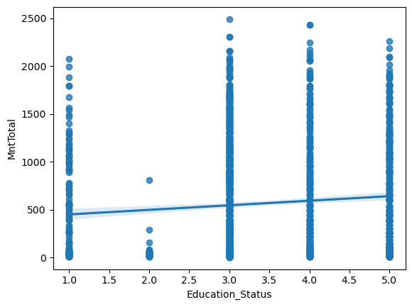

```python
# regression plot of Education Status vs Accepted Campaigns
sns.regplot(x = 'Education_Status', y = 'MntTotal', data = food)
```

### Education Status does not show strong correlation with Total Amount Spent and Campaign Acceptance.

### Education isn't really significant in our segmentation.

## Marital Status Segmentation

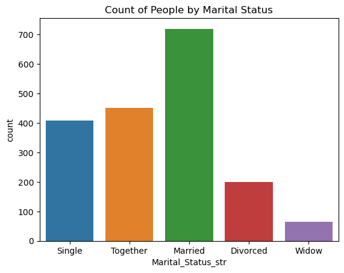

```python
# count by marital status
sns.countplot(x = 'Marital_Status_str', data = food)
plt.title('Count of People by Marital Status')
```

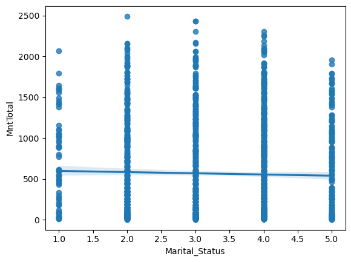

```python
# regression plot of Marital Status vs Total Amount Spent
sns.regplot(x = 'Marital_Status', y = 'MntTotal', data = food)
```

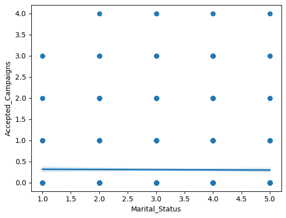

```python
# regression plot of Marital Status vs Accepted Campaigns
sns.regplot(x = 'Marital_Status', y = 'Accepted_Campaigns', data = food)
```

### Looks like Marital Status does not have any strong correlation with Total Amount Spent and Campaign Acceptance so far.

But let's run the calculations again.

```python
# total amount spent by Marital Status
food.groupby('Marital_Status_str')['MntTotal'].sum()
```

```
Marital_Status_str
Divorced    111813
Married     397442
Single      231616
Together    254606
Widow        46014
Name: MntTotal, dtype: int64
```

### It shows that Married, Single and Together are spending a lot more than Divorced and Widow people.

```python
# who accepted campaigns
accpt = food[food['Accepted_Campaigns'] != 0]

rel_food = accpt.groupby('Marital_Status_str')['MntTotal'].sum().reset_index()
```

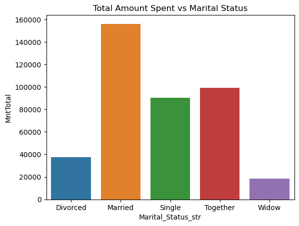

```python
# visualizinf total amount spent by marital status who accepted campaign/s
sns.barplot(x = 'Marital_Status_str', y = 'MntTotal', data = rel_food)
plt.title('Total Amount Spent vs Marital Status')
```

### Update: Married, single, together are spending a lot more money than widow and divorced. We should focus on this segment.

```python
# % of marital status who accepts 1 campaign
total = food['Marital_Status_str'].value_counts()
accepted = food[food['Accepted_Campaigns'] == 1]['Marital_Status_str'].value_counts()
```

```python
pect_marital = accepted / total * 100
```

```python
pect_food = pect_marital.reset_index()
pect_food.columns = ['Marital_Status', 'Percentage']
```

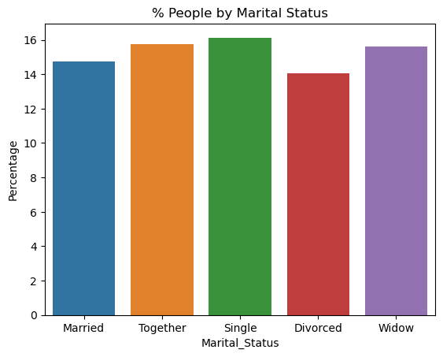

```python
sns.barplot(x = 'Marital_Status', y = 'Percentage', data = pect_food)
plt.title('% People by Marital Status')
```

# OVERALL FINDINGS

### 1. Age: Customers aged 30-70 were spending more money overall, but they are less likely to accept campaigns. (To consider: There is higher volume of these age groups in the data.

### 2. Sales Channels: Catalog buyers are more likely to accept campaigns, while in-store buyers spend the most. A balanced investment across channels is required.

- Suggested allocation: 40% catalog, 30% store, 30% web

### 3. Household Structure: Customers with no children or fewer children show higher campaign acceptance rates, and higher spending rates, making them a strong priority for targeting.

### 4. Education: Has no significant impact on acceptance and spending rates - no need to target by education level.

### 5. Marital Status - Not a major driver of campaign acceptance, but Married, Single, Together customers spend more money compared to Divorced or Widow customers.

# Recommendations

### 2.Allocate marketing spend as 40% catalog / 30% store / 30% web

to balance responsiveness, in-store value, and web reach

### 3. Leverage Household Targeting:

Prioritize campaigns for households with no or fewer children, where acceptance and spending rates are highest.

### 4. Avoid Over-Segmenting by Education

Since education level has little effect, resources should be redirected toward behavioral and demographic factors with stronger predictive power.

### 5. New Users to Spend Money

Focus on Younger(20-30) and older (70+) age groups - who accepted campaigns at a higher rate.